# PML Project

Amanda Pedersen

February 25, 2016

# Introduction

#### Fitness devices such as Fitbit and Jawbone Up, have become very popular for collecting large amounts of data related to physical activity. They are used to find patterns in fitness behavior or to improve health. Most commonly, these devices are used to quantify how much of an activity the wearer accomplishes. In this project, we will use data from accelerometers on the belt, forearm, arm, and dumbell of 6 indiviual participants. This data will then be used to predict the manner in which each exercise was completed.

# Loading Dependencies

```r
library(caret)
```

```r
library(rpart)
library(rpart.plot)
library(randomForest)
library(corrplot)
```

# Extract the Data

```r
download.file("https://d396qusza40orc.cloudfront.net/predmachlearn/pml-training.csv", destfile = "pml-training.csv")
download.file("https://d396qusza40orc.cloudfront.net/predmachlearn/pml-testing.csv", destfile = "pml-testing.csv")
```

# Read the Extracted Data

```r
trainData <- read.csv("pml-training.csv")
testData <- read.csv("pml-testing.csv")
dim(trainData)
```

```
## [1] 19622   160
```

```r
dim(testData)
```

```
## [1]  20 160
```

#### The dimensions show that the training data set contains 19,622 observations of 160 variables. The testing set contains 20 observations. The “classe” variable in the training set is the prediction outcome.

# Clean the Data

#### In order to make the data usable, the missing values and unimportant variables must be removed. This will reduce the number of variables to 53. The number of observations remains the same.

```r
sum(complete.cases(trainData))
```

```
## [1] 406
```

```r
trainData <- trainData[, colSums(is.na(trainData)) == 0]
testData <- testData[, colSums(is.na(testData)) == 0]
classe <- trainData$classe
trainRemove <- grepl("^X|timestamp|window", names(trainData))
trainData <- trainData[, !trainRemove]
trainCleaned <- trainData[, sapply(trainData, is.numeric)]
trainCleaned$classe <- classe
testRemove <- grepl("^X|timestamp|window", names(testData))
testData <- testData[, !testRemove]
testCleaned <- testData[, sapply(testData, is.numeric)]
```

# Data Modeling

#### Now that the data has been cleaned, a validation set must be created. The training set will be split 70/30, so 30% of the observations will now become part of the validation set. Then a predictive model will be fit to the data. The Random Forest algorithm will be used for activity prediction. Finally, the model is applied to the original testing data set.

```r
set.seed(14)
inTrain <- createDataPartition(y=trainCleaned$classe, p=0.70, list = FALSE)
trainFinal <- trainCleaned[inTrain, ]
validation <- trainCleaned[-inTrain, ]
```

```r
controlRf <- trainControl(method = "cv", 5)
modelRF <- train(classe ~ ., data=trainFinal, method="rf", trControl=controlRf, ntree=250)
modelRF
```

```
## Random Forest
##
## 13737 samples
##    52 predictor
##     5 classes: 'A', 'B', 'C', 'D', 'E'
##
## No pre-processing
## Resampling: Cross-Validated (5 fold)
## Summary of sample sizes: 10988, 10989, 10991, 10990, 10990
## Resampling results across tuning parameters:
##
##   mtry  Accuracy   Kappa      Accuracy SD  Kappa SD
##    2    0.9899541  0.9872907  0.001377129  0.001743304
##   27    0.9895905  0.9868320  0.003071910  0.003885797
##   52    0.9820922  0.9773428  0.004677677  0.005921108
##
## Accuracy was used to select the optimal model using  the largest value.
## The final value used for the model was mtry = 2.
```

```r
result <- predict(modelRF, testCleaned[, -length(names(testCleaned))])
result
```

```
##  [1] B A B A A E D B A A B C B A E E A B B B
## Levels: A B C D E
```

# Appendix: Figures

#### 1. Correlation Matrix Figure

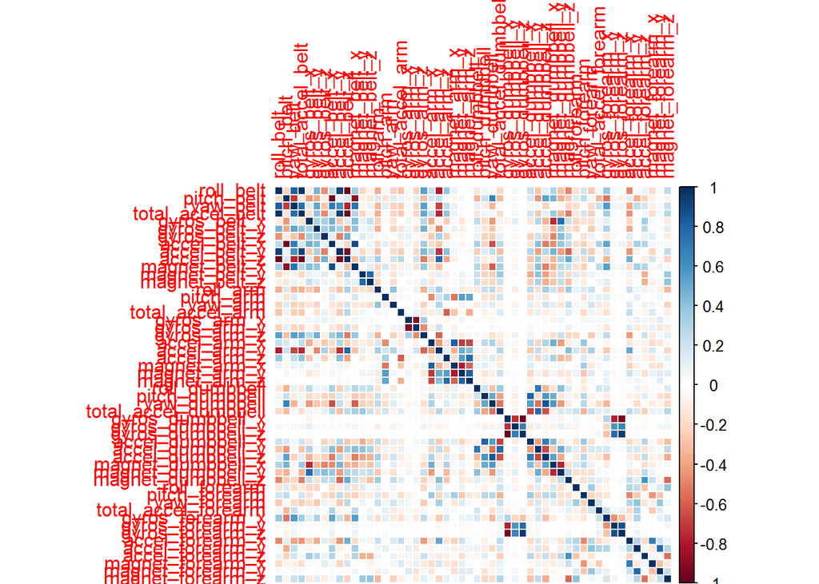

####2. Decision Tree Figure

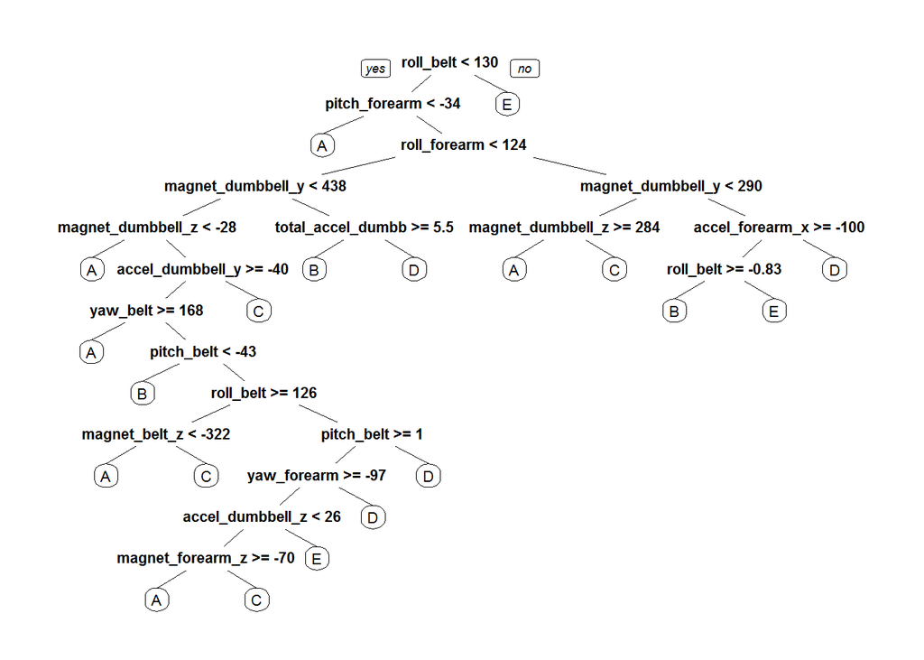